# Exploratory Data Analysis

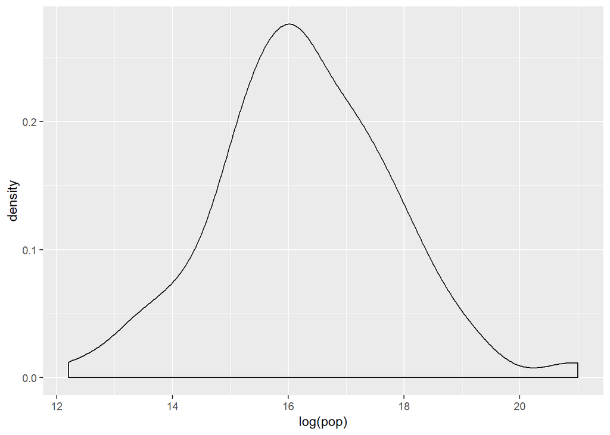

```r
#Create density plot of log(pop)
gap2007 %>%
  ggplot(aes(x = log(pop))) +
  geom_density()
```

The difference is much easier to see on a log scale.

**Outliers**

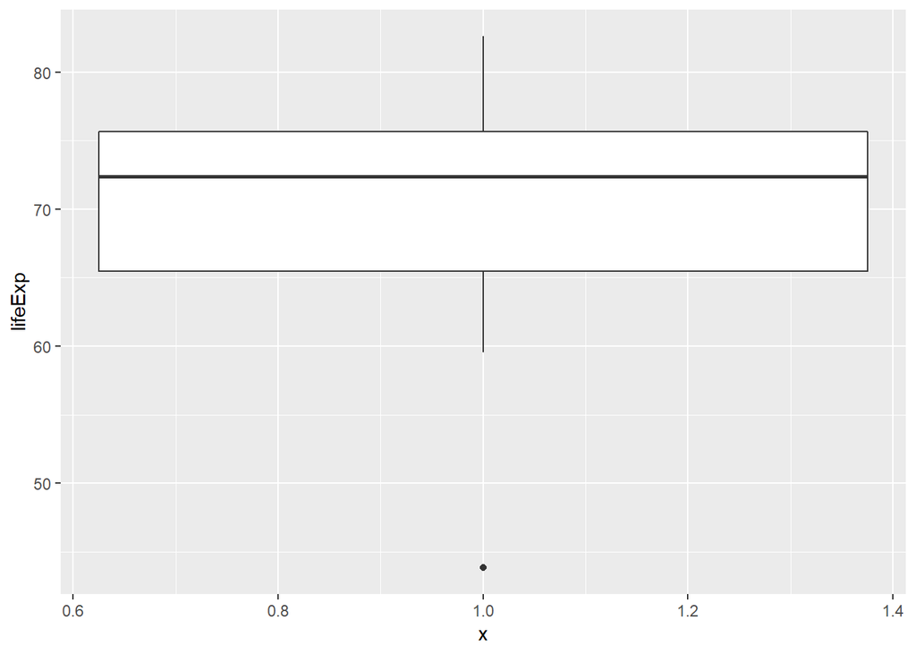

```r
#Outliers
gap_asia <- gap2007 %>%
  filter(continent == 'Asia') %>%
  mutate(is_outlier = lifeExp < 50)
#Create box plot of lifeExp with outliers
gap_asia %>%
  ggplot(aes(x = 1, y = lifeExp)) +
  geom_boxplot()
```

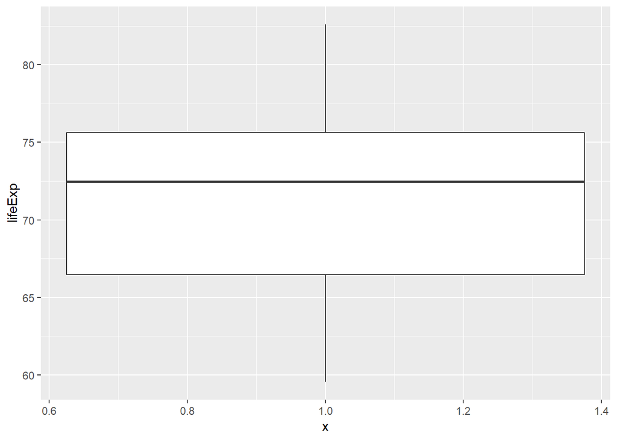

```r
#Create box plot of lifeExp without outliers
gap_asia %>%
  filter(!is_outlier) %>%
  ggplot(aes(x = 1, y = lifeExp)) +
  geom_boxplot()
```

# **Case Study**

**Spam & Num_char**

```r
library(openintro)
head(email, 3)
```

```
##   spam to_multiple from cc sent_email                time image attach
## 1    0           0    1  0          0 2012-01-01 14:16:41     0      0
## 2    0           0    1  0          0 2012-01-01 15:03:59     0      0
## 3    0           0    1  0          0 2012-01-02 00:00:32     0      0
##   dollar winner inherit viagra password num_char line_breaks format
## 1      0     no       0      0        0    11.37         202      1
## 2      0     no       0      0        0    10.50         202      1
## 3      4     no       1      0        0     7.77         192      1
##   re_subj exclaim_subj urgent_subj exclaim_mess number
## 1       0            0           0            0    big
## 2       0            0           0            1  small
## 3       0            0           0            6  small
```

```r
#Compute summary statistics
email %>%
  group_by(spam) %>%
  summarize(median(num_char), IQR(num_char))
```

```
## # A tibble: 2 x 3
##    spam `median(num_char)` `IQR(num_char)`
##   <dbl>              <dbl>           <dbl>
## 1     0               6.83           13.6
## 2     1               1.05            2.82
```

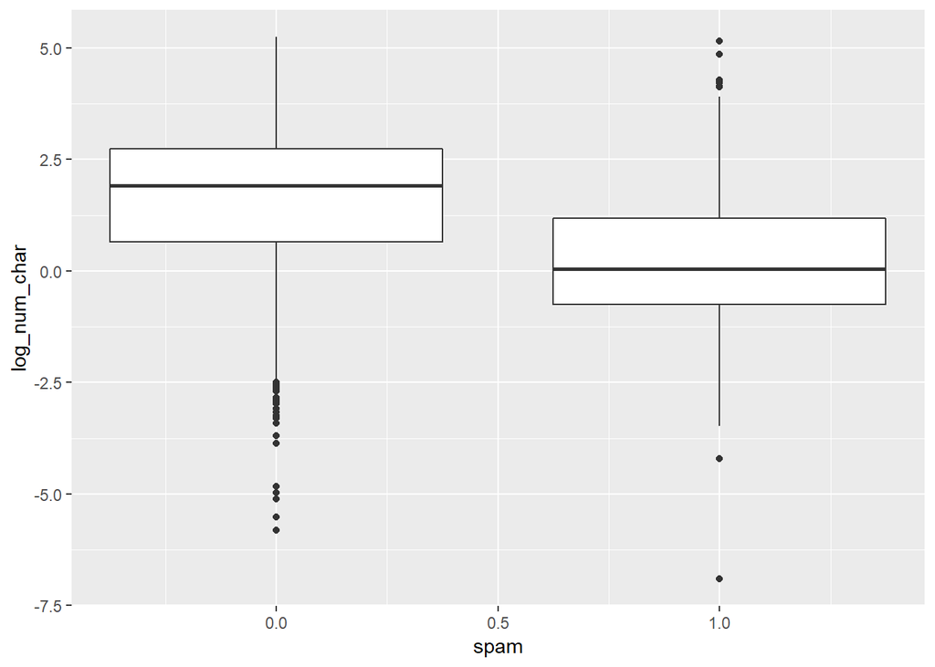

```r
#Create plot
email %>%
  mutate(log_num_char = log(num_char)) %>%
  ggplot(aes(x = spam, y = log_num_char, group = spam)) +
  geom_boxplot()
```

According to the graphs, the median length of not-spam emails is greater than that of spam emails.

**Spam & exclaim_mess**

```r
#Compute center and spread for exclaim_mess by spam
email %>%
  group_by(spam) %>%
  summarize(median(exclaim_mess), IQR(exclaim_mess))
```

```
## # A tibble: 2 x 3
##    spam `median(exclaim_mess)` `IQR(exclaim_mess)`
##   <dbl>                  <dbl>               <dbl>
## 1     0                      1                   5
## 2     1                      0                   1
```

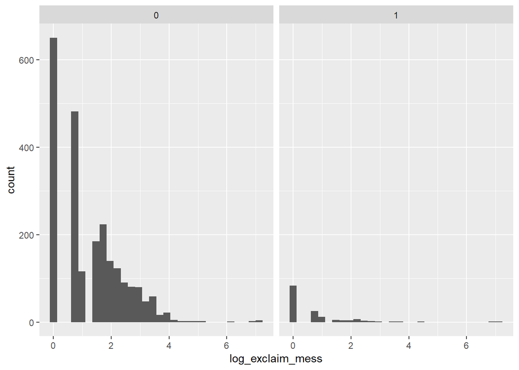

```r
#Create plot for spam and exclaim_mess
email %>%
  mutate(log_exclaim_mess = log(exclaim_mess)) %>%
  ggplot(aes(x = log_exclaim_mess)) +
  geom_histogram() +
  facet_wrap(~ spam)
```

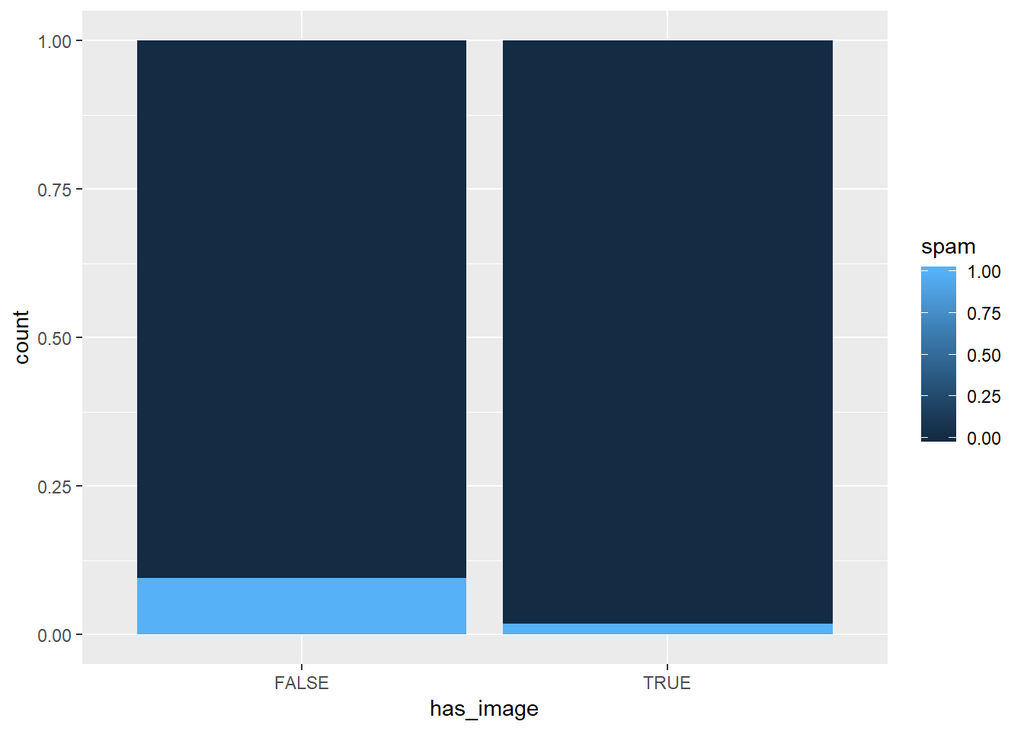

```r
#Create plot of proportion of spam by image
email %>%
  mutate(has_image = image > 0) %>%
  ggplot(aes(x = has_image, fill = spam, group = spam)) +
  geom_bar(position = 'fill')
```

Obviously, an email without an image is more likely to be not-spam than spam.

**Strategy for Testing**

```r
#Test if images count as attachments
sum(email$image > email$attach)
```

```
## [1] 0
```

Since image is never greater than attach, we can infer that images are counted as attachments.

**Question 1:**  
For emails containing the word “dollar”, does the typical spam email contain a greater number of occurrences of the word than the typical non-spam email?  
Create a summary statistic that answers this question.

```r
email %>%
  filter(dollar > 0) %>%
  group_by(spam) %>%
  summarize(median(dollar))
```

```
## # A tibble: 2 x 2
##    spam `median(dollar)`
##   <dbl>            <dbl>
## 1     0                4
## 2     1                2
```

**Question 2:**  
If you encounter an email with greater than 10 occurrences of the word “dollar”, is it more likely to be spam or not-spam?  
Create a barchart that answers this question.

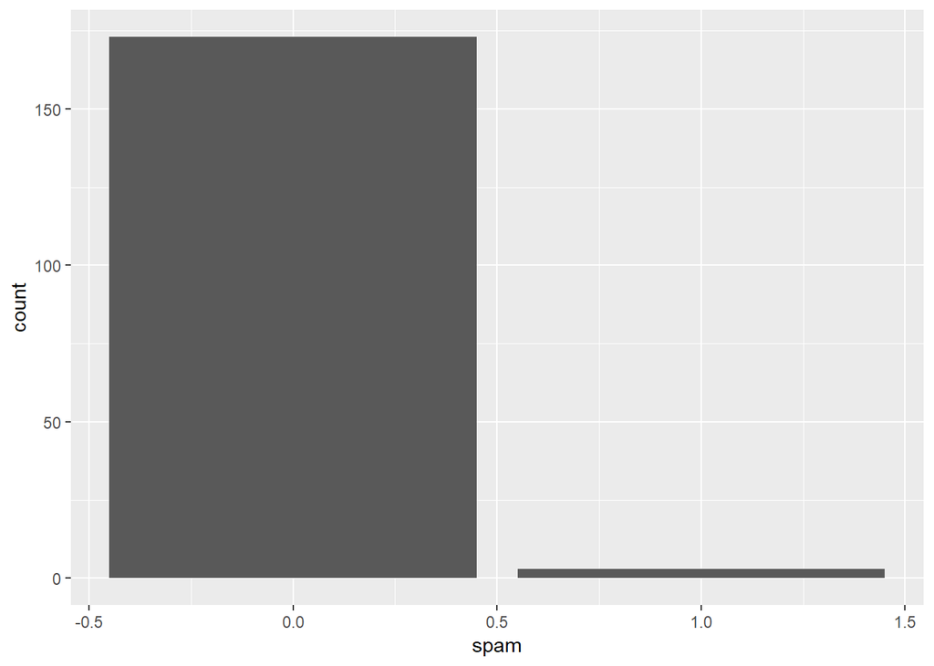

```r
email %>%
  filter(dollar > 10) %>%
  ggplot(aes(x = spam)) +
  geom_bar()
```

**Spam & NUmbers**

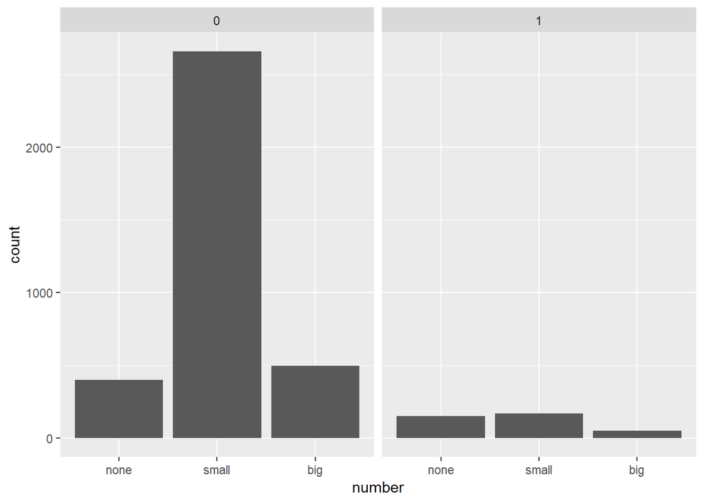

```r
# Reorder levels
email$number = factor(email$number, order = T, levels = c('none','small','big'))

# Construct plot of number
ggplot(email, aes(x = number)) +
  geom_bar() +
  facet_wrap(~spam)
```